# Manipulating Graph Data

Joshua Clark

10/2/2015

This lab is going to be a bit of review and a bit of new stuff. We are going to be looking at the various ways we can manipulate, control and otherwise deal with graph data. Certain aspects of this content have been covering piecemeal throughout the course of the semester but this should condense it all into a nice unified set of code.

### Vertex Attributes

Vertex attributes are often really important for social science research using networks. They can capture many types of information about a particular node and can be interval, ordinal or nominal.

iGraph handles vertex attributes through a special data frame called the vertex frame. Let’s load the Enron data again as it has a number of attributes which we can play around with.

```r
library(igraph)
enr<-read.graph('enron-good.graphml', format='graphml')
enr
```

```
## IGRAPH D--- 184 125409 -- Enron email network
## + attr: LDC_names (g/c), LDC_desc (g/c), name (g/c), Citation
## | (g/c), Email (v/c), Name (v/c), Note (v/c), id (v/c), Time
## | (e/c), Reciptype (e/c), Topic (e/n), LDC_topic (e/n)
## + edges:
##  [1]  25->154  25->154  30-> 30  30-> 30  30-> 30  30-> 30  39-> 39
##  [8]  52-> 67  52-> 67  52-> 67  52-> 67  61->100  61->100  61->163
## [15]  61->163  61->166  61->166  61->170  64-> 59  64-> 59  64-> 64
## [22]  64-> 64  64->147  64->147  64->164  64->164  64->168  66-> 66
## [29]  66-> 66  67->129  67->129  67->129  67->129  93-> 10  93-> 10
## [36]  93-> 10  93-> 10  93-> 39  93-> 39  93-> 93  93-> 93  93-> 93
## + ... omitted several edges
```

```r
set.seed(11)
```

Looking at the graph we have a number of vertex attributes including name, email and note (the person’s position within Enron).

We can create new vertex attributes by passing a vector of values to the V() function. The values are assigned to nodes in order that they are entered, so the first row goes to whichever row is first in your data set (in this case Albert Meyers). Keep this in mind when sorting data as it can break the ordering of rows

Often times it is extremely handy to store network metrics within a particular network as attributes. This ensure that each node is associated with its particular scores even if you reorder, subset or sort the network.

```r
V(enr)$in.degree<-degree(enr, mode='in')
V(enr)$out.degree<-degree(enr, mode='out')
V(enr)$eigen.cent<-evcent(enr)$vector
V(enr)$in.degree
```

```
##   [1]    78   335   224    88   623   211  1408   114   143   722   257
##  [12]   326   245   231   238    82   137   713    72   148   270   412
##  [23]   557   497    75   238   187  1360    35   505   344     6   204
##  [34]   642   774    72   656   407  1485   885   191   655    16   217
##  [45]    37    78   208   667   289   317   868  1648    40   218   106
##  [56]   147   455   425  5005   265   480   737   922  3227   194  2339
##  [67]  1382   391    73   374   261     6   257   588   191   247    60
##  [78]   181   989    67   485   228  3415   281   303   259   204    23
##  [89]  1081   629   647   485   780   947   537  1078   632   221  1035
## [100]   436   249   436   437   859   206   388   143  2198  1041   235
## [111]  1797    28  1068   559  3811   622   181     1  2153   193   486
## [122]    68    33   288  1196   177  1106   631   802   284   285    47
## [133]   661   448   348    17   535    81    29   149   723   810   110
## [144]   176   108  1896  6962   839   931   176    68   762   285   609
## [155]   204  2724   603   953  1265   483  1039   607  1310  2773   151
## [166]  2019   172  1697    35  2301   328   146   433   299   229    72
## [177]   769   565 10392   144    62    97    39   237
```

These attributes can be manipulated or used in calculations just like any other variable in a data frame.

```r
V(enr)$total.degree<-V(enr)$in.degree+V(enr)$out.degree
mean(V(enr)$in.degree)
```

```
## [1] 681.5707
```

```r
sd(V(enr)$out.degree)
```

```
## [1] 1510.891
```

The easiest way to think of vertex attributes within iGraph to think of a distinct data frame within the graph that can be accessed through the get.vertex.attribute() function. Let’s take a look at it now.

```r
enr.v.attri<-get.vertex.attribute(enr)
head(enr.v.attri)$in.degree
```

```
##   [1]    78   335   224    88   623   211  1408   114   143   722   257
##  [12]   326   245   231   238    82   137   713    72   148   270   412
##  [23]   557   497    75   238   187  1360    35   505   344     6   204
##  [34]   642   774    72   656   407  1485   885   191   655    16   217
##  [45]    37    78   208   667   289   317   868  1648    40   218   106
##  [56]   147   455   425  5005   265   480   737   922  3227   194  2339
##  [67]  1382   391    73   374   261     6   257   588   191   247    60
##  [78]   181   989    67   485   228  3415   281   303   259   204    23
##  [89]  1081   629   647   485   780   947   537  1078   632   221  1035
## [100]   436   249   436   437   859   206   388   143  2198  1041   235
## [111]  1797    28  1068   559  3811   622   181     1  2153   193   486
## [122]    68    33   288  1196   177  1106   631   802   284   285    47
## [133]   661   448   348    17   535    81    29   149   723   810   110
## [144]   176   108  1896  6962   839   931   176    68   762   285   609
## [155]   204  2724   603   953  1265   483  1039   607  1310  2773   151
## [166]  2019   172  1697    35  2301   328   146   433   299   229    72
## [177]   769   565 10392   144    62    97    39   237
```

This gives us a list of vectors, we can also pull the information out as a data frame with the get.data.frame function.

```r
enr.v.data<-get.data.frame(enr, what='vertices')
head(enr.v.data)
```

```
##           Email             Name                         Note id in.degree
## 1 albert.meyers    Albert Meyers         Employee, Specialist n0        78
## 2     a..martin    Thomas Martin               Vice President n1       335
## 3   andrea.ring      Andrea Ring                           NA n2       224
## 4  andrew.lewis     Andrew Lewis                     Director n3        88
## 5   andy.zipper      Andy Zipper Vice President, Enron Online n4       623
## 6   a..shankman Jeffrey Shankman President, Enron Global Mkts n5       211
##   out.degree   eigen.cent total.degree
## 1         36 1.134885e-05          114
## 2         93 2.161958e-04          428
## 3        167 4.695112e-05          391
## 4         16 2.783482e-05          104
## 5        334 1.091843e-03          957
## 6        170 2.145919e-04          381
```

### Edge Attributes

Edges are treated the same way, except with the E descriptor.

```r
E(enr)
```

```
## + 125409/125409 edges:
##  [1]  25->154  25->154  30-> 30  30-> 30  30-> 30  30-> 30  39-> 39
##  [8]  52-> 67  52-> 67  52-> 67  52-> 67  61->100  61->100  61->163
## [15]  61->163  61->166  61->166  61->170  64-> 59  64-> 59  64-> 64
## [22]  64-> 64  64->147  64->147  64->164  64->164  64->168  66-> 66
## [29]  66-> 66  67->129  67->129  67->129  67->129  93-> 10  93-> 10
## [36]  93-> 10  93-> 10  93-> 39  93-> 39  93-> 93  93-> 93  93-> 93
## [43]  93-> 93  93->124  93->124 100-> 61 100-> 61 115->115 115->115
## [50] 115->115 115->115 125-> 96 125->104 125->125 125->125 138-> 57
## [57] 138-> 57 141-> 57 141-> 57 141-> 79 141-> 79 141-> 83 141-> 83
## [64] 141->158 141->158 141->174 141->174 146-> 28 146-> 28 146-> 52
## + ... omitted several edges
```

```r
enr.e.data<-get.data.frame(enr, what='edges')
head(enr.e.data)
```

```
##   from  to                Time Reciptype Topic LDC_topic
## 1   25 154 1979-12-31 21:00:00        to     1         0
## 2   25 154 1979-12-31 21:00:00        to     1        -1
## 3   30  30 1979-12-31 21:00:00        cc     3        -1
## 4   30  30 1979-12-31 21:00:00        cc     3        -1
## 5   30  30 1979-12-31 21:00:00       bcc     3        -1
## 6   30  30 1979-12-31 21:00:00       bcc     3        -1
```

Just like node attributes edge attributes can be manipulated or summarized.

```r
head(E(enr)$Reciptype)
```

```
## [1] "to"  "to"  "cc"  "cc"  "bcc" "bcc"
```

```r
table(E(enr)$Reciptype)
```

```
##
##   bcc    cc    to
## 22193 22193 81023
```

Some of you have mentioned looking at networks over time. Dates and times are handled a little differently in R. Given the thousands of different formats there is no generic data class for dates. Instead we have to translate our dates into a format that R can read, at which point we can filter by year, month, day, hour, minutes, seconds or other factors. The standard R interface for managing dates is cumbersome so let’s install an alternative, lubridate.

```r
install.packages('lubridate')
```

Lubridate let’s you specify the data structure with Y,m,d,H,M,S standing for year, month, day, hours, minutes and seconds respectively. Any separator such as hyphens need to be included as well.

Once the date has been converted into an R readable format it is easy to extract elements such as month or year and assign them back as edge attributes.

```r
library(lubridate)
```

```r
library(ggplot2)
good.date<-parse_date_time(E(enr)$Time, order='Y-m-d H:M:S')
head(good.date)
```

```
## [1] "1979-12-31 21:00:00 UTC" "1979-12-31 21:00:00 UTC"
## [3] "1979-12-31 21:00:00 UTC" "1979-12-31 21:00:00 UTC"
## [5] "1979-12-31 21:00:00 UTC" "1979-12-31 21:00:00 UTC"
```

```r
E(enr)$month<-ordered(month(good.date, label=TRUE))
E(enr)$year<-year(good.date)
E(enr)$day<-day(good.date)
head(E(enr)$month)
```

```
## [1] 12 12 12 12 12 12
```

```r
dates.table<-table(month(good.date, label=TRUE), year(good.date))
dates.table
```

```
##
##        1979  1998  1999  2000  2001  2002
##   Jan     0     0   100  1786  6808  3450
##   Feb     0     0    12  1552  6665  4025
##   Mar     0     0    24  2005  7085   791
##   Apr     0     0     4  1766  7435   102
##   May     0     0   155  2013  7808    84
##   Jun     0     0   130  2859  3014    39
##   Jul     0     0   248  3183  3192     0
##   Aug     0     0   319  5298  2777     0
##   Sep     0     0   434  4495  3762     0
##   Oct     0     0   494  6244 10796     0
##   Nov     0    30   310  6502  7243     0
##   Dec   174    52  1485  6356  2303     0
```

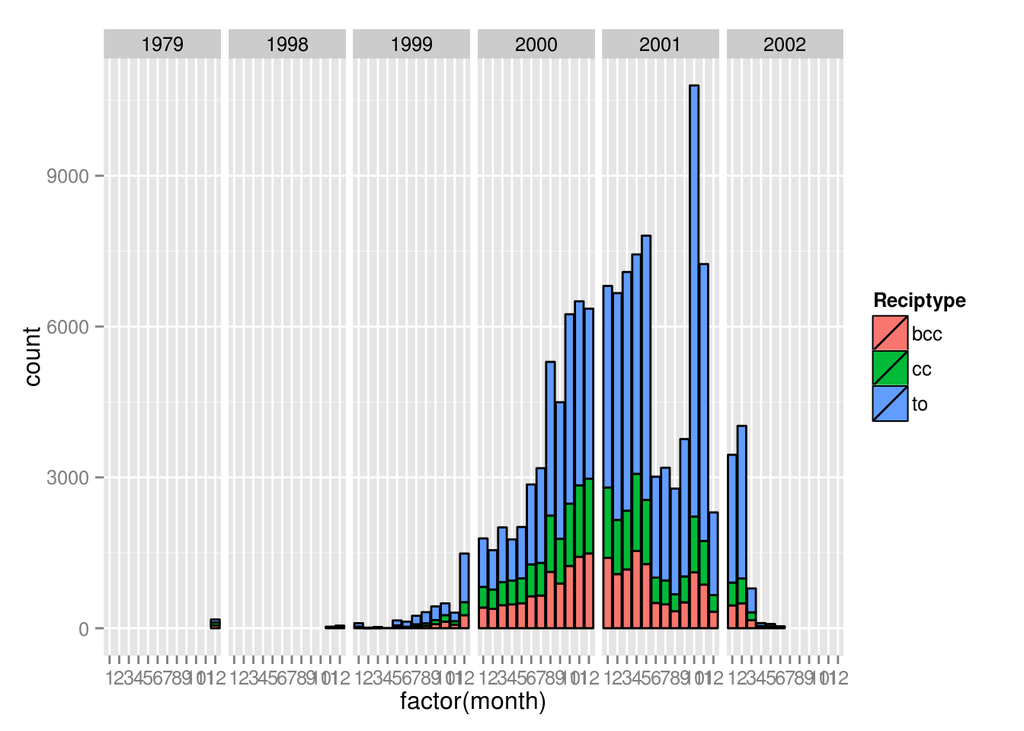

```r
enr.edges<-get.data.frame(enr)
ggplot(enr.edges, aes(x=factor(month), fill=Reciptype))+geom_bar(color='black')+facet_grid(.~year)
```

The Enron scandal broke in October of 2001, and we can see a spike in email traffic around that time as well.

### Adding or Deleting Data.

Sometimes networks will have superfluous edges or nodes in them. If we delete these in the raw data it can mess up the network construction. But if we delete the offending data inside igraph it will automatically adjust to take these changes into account.

#### Removing Nodes

You may have noticed that there we a number of nodes with “NA” as their name within the network. These are folks who have been removed from the data set for legal reasons by the FBI. While it may be interesting to keep them in let’s go through and remove these nodes to clean up our data set and make it easier to read.

```r
table(V(enr)$Name=='NA')
```

```
##
## FALSE  TRUE
##   160    24
```

```r
enr.trim<-delete.vertices(enr, V(enr)$Name=='NA')
table(V(enr.trim)$Name=='NA')
```

```
##
## FALSE
##   160
```

```r
table(E(enr.trim)$year)
```

```
##
##  1979  1998  1999  2000  2001  2002
##   140    74  2610 37024 55985  5371
```

```r
enr.trim2<-delete.edges(enr.trim, which(E(enr)$year < 1999))
table(E(enr.trim2)$year)
```

```
##
##  1999  2000  2001  2002
##  2568 37024 55985  5371
```

## Extracting and Merging Networks.

Oftentimes a researcher will have a large network and want to subset downwards to look at specific communities or sub communities. There are a few levels of specificity that we can look at within networks, sub networks or ego-networks.

#### Sub-Networks on Node Attributes

One way to subset down is to look at a network who share some common criteria based on their node attributes. As an example, within a friendship network you could extract all of the members of a community who identify as a particular gender, or who are above or below a given age threshold. Let’s generate an ego network containing all of the Enron employee’s who have a job description that includes the word president.

Grepl is a form of regular expression (regex), essentially a way to do complex text searches. Regexp can get complicated fast but it is easy to search for a simple string like “President”

```r
grepl('President', V(enr.trim2)$Note)
```

```
##   [1] FALSE  TRUE FALSE FALSE  TRUE  TRUE  TRUE FALSE FALSE FALSE  TRUE
##  [12] FALSE FALSE FALSE FALSE FALSE FALSE FALSE  TRUE FALSE  TRUE FALSE
##  [23] FALSE FALSE FALSE FALSE FALSE  TRUE FALSE  TRUE  TRUE FALSE FALSE
##  [34] FALSE FALSE FALSE FALSE FALSE FALSE FALSE  TRUE FALSE FALSE FALSE
##  [45] FALSE  TRUE  TRUE FALSE FALSE  TRUE FALSE  TRUE  TRUE FALSE FALSE
##  [56] FALSE FALSE FALSE  TRUE FALSE FALSE FALSE FALSE FALSE  TRUE FALSE
##  [67] FALSE  TRUE  TRUE FALSE FALSE FALSE  TRUE FALSE  TRUE FALSE FALSE
##  [78] FALSE FALSE FALSE FALSE FALSE FALSE FALSE  TRUE FALSE FALSE FALSE
##  [89] FALSE FALSE FALSE FALSE FALSE  TRUE FALSE FALSE FALSE FALSE FALSE
## [100] FALSE FALSE FALSE FALSE FALSE FALSE FALSE FALSE FALSE FALSE FALSE
## [111] FALSE FALSE FALSE FALSE  TRUE FALSE  TRUE FALSE FALSE FALSE FALSE
## [122] FALSE FALSE FALSE FALSE  TRUE  TRUE FALSE FALSE FALSE  TRUE FALSE
## [133] FALSE FALSE  TRUE  TRUE  TRUE FALSE  TRUE FALSE  TRUE FALSE FALSE
## [144] FALSE FALSE FALSE FALSE FALSE FALSE  TRUE FALSE FALSE FALSE FALSE
## [155] FALSE FALSE FALSE FALSE FALSE FALSE
```

This TRUE/FALSE vector can be used to extract a sub graph featuring nodes that only have a TRUE flag. This let’s us examine a network of all the emails between presidents within Enron.

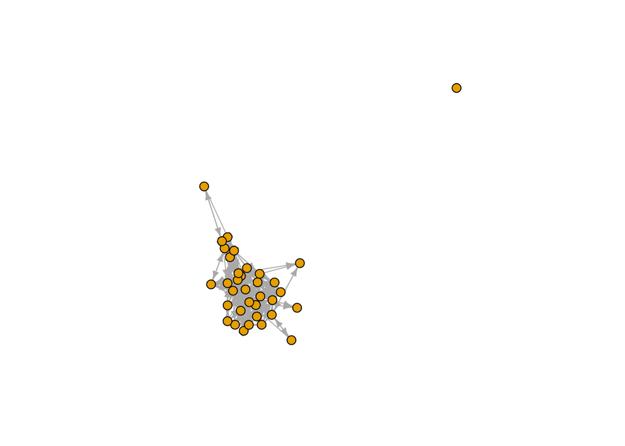

```r
enr.prez<-induced.subgraph(enr.trim2, vids=grepl('President', V(enr.trim2)$Note))
l<-layout.fruchterman.reingold(enr.prez)
plot(simplify(enr.prez), edge.arrow.size=0.5, layout=l, vertex.label=NA, vertex.size=7)
```

```r
table(V(enr.prez)$Note)
```

```
##
##                                                  President
##                                                          1
##                              President, Enron Gas Pipeline
##                                                          1
##                               President, Enron Global Mkts
##                                                          2
##                                    President, Enron Online
##                                                          1
##                                             Vice President
##                                                         18
## Vice President, Also Chief Financial Officer and Treasurer
##                                                          1
##       Vice President, Enery marketting and trading Florida
##                                                          1
##                               Vice President, Enron Online
##                                                          1
##                   Vice President, Enron WholeSale Services
##                                                          2
##                         Vice President, Government Affairs
##                                                          2
##                         Vice President, Regulatory Affairs
##                                                          2
##                                       Vice President, Term
##                                                          1
##            Vice President, Vice President & Chief of Staff
##                                                          2
```

Graphs can be subseted on multiple conditions as long as it produces a logical TRUE/FALSE vector. So we can pull out residents with a exceptionally high in degree

```r
enr.prez.2000<-induced.subgraph(enr.trim2, vids= grepl('President',  V(enr.trim2)$Note) & V(enr.trim2)$in.degree >=2000)
enr.prez.2000
```

```
## IGRAPH D--- 4 5550 -- Enron email network
## + attr: LDC_names (g/c), LDC_desc (g/c), name (g/c), Citation
## | (g/c), Email (v/c), Name (v/c), Note (v/c), id (v/c), in.degree
## | (v/n), out.degree (v/n), eigen.cent (v/n), total.degree (v/n),
## | Time (e/c), Reciptype (e/c), Topic (e/n), LDC_topic (e/n), month
## | (e/n), year (e/n), day (e/n)
## + edges:
##  [1] 1->1 1->1 1->1 1->1 1->1 1->1 1->1 1->1 1->1 1->1 1->1 1->1 1->1 1->1
## [15] 1->1 1->1 1->1 1->2 1->2 1->2 1->2 1->2 1->2 1->2 1->2 1->2 1->2 1->2
## [29] 1->2 1->2 1->2 1->2 1->2 1->2 1->2 1->2 1->2 1->2 1->2 1->2 1->2 1->2
## [43] 1->2 1->2 1->2 1->2 1->2 1->2 1->2 1->2 1->2 1->2 1->2 1->2 1->2 1->2
## + ... omitted several edges
```

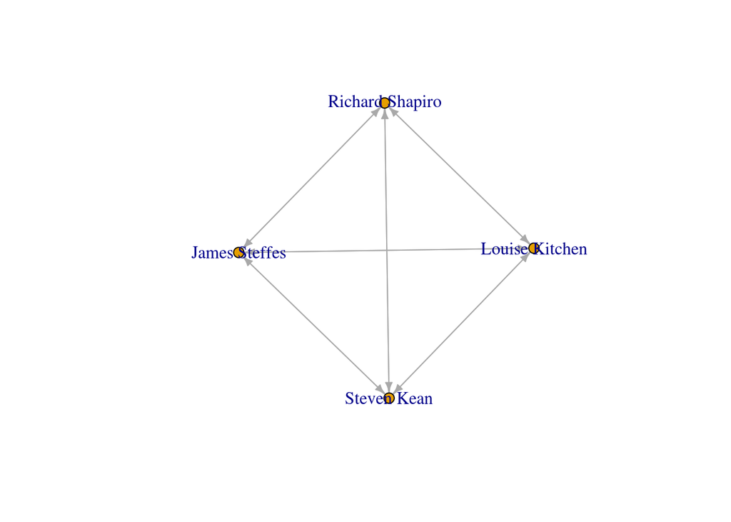

```r
plot(simplify(enr.prez.2000), edge.arrow.size=0.5, vertex.size=7, vertex.label=V(enr.prez.2000)$Name)
```

We can also induce sub graphs based on edges. We generated edge attributes with a month and year earlier in this exercise, let’s extract all of the emails from the month of the scandal. We need to wrap our selection logic with *which* so that it returns a numeric index of what edges we are selecting.

```r
demos<-c(1,13,19,25,66)
demos>3 & demos<10
```

```
## [1] FALSE FALSE FALSE FALSE FALSE
```

```r
which(demos>3 & demos<20)
```

```
## [1] 2 3
```

```r
demos[which(demos>3 & demos<20)]
```

```
## [1] 13 19
```

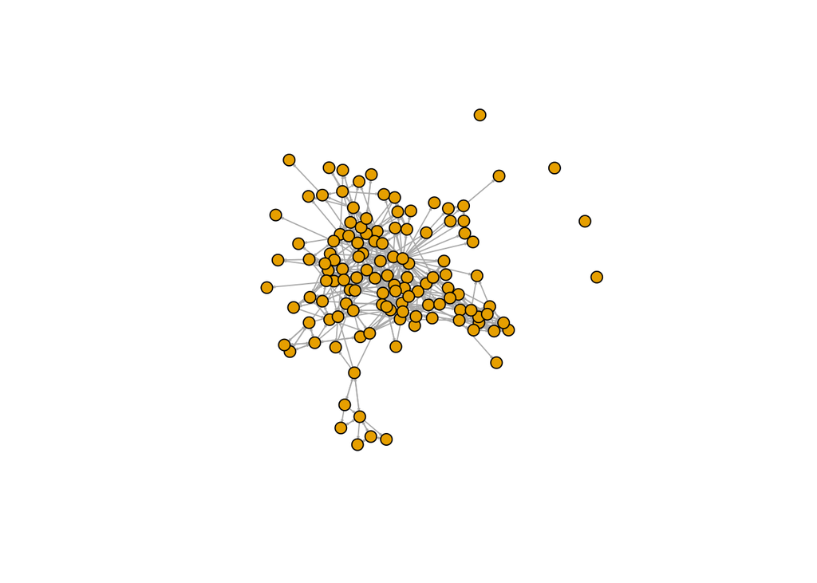

```r
enr.crisis<-subgraph.edges(enr.trim2, which(E(enr.trim2)$month=="10" & E(enr.trim2)$year=="2001"))
plot(simplify(enr.crisis), edge.arrow.size=0.1, vertex.label=NA, vertex.size=7)
```

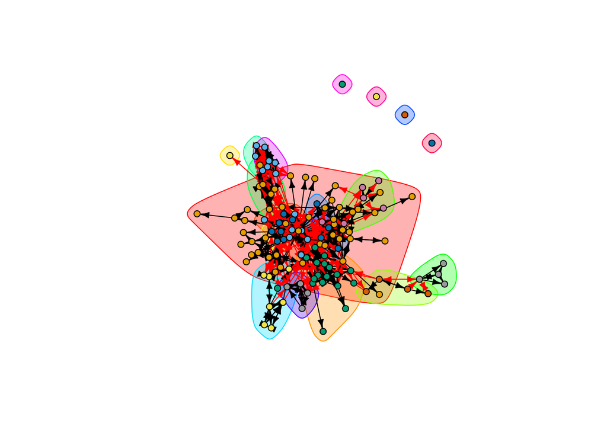

```r
enr.com<-label.propagation.community(enr.crisis)
enr.mem<-membership(enr.com)
V(enr.crisis)$membership<-enr.mem
plot(enr.com, simplify(enr.crisis), edge.arrow.size=0.5, vertex.label=NA, vertex.size=5)
```

```r
table(V(enr.crisis)$membership)
```

```
##
##  1  2  3  4  5  6  7  8  9 10 11 12 13 14 15 16 17 18 19 20 21
## 43  7 17  1  7  4  5  4  6  3  1  7  4  1  1  4  1  5  1  1  1
```

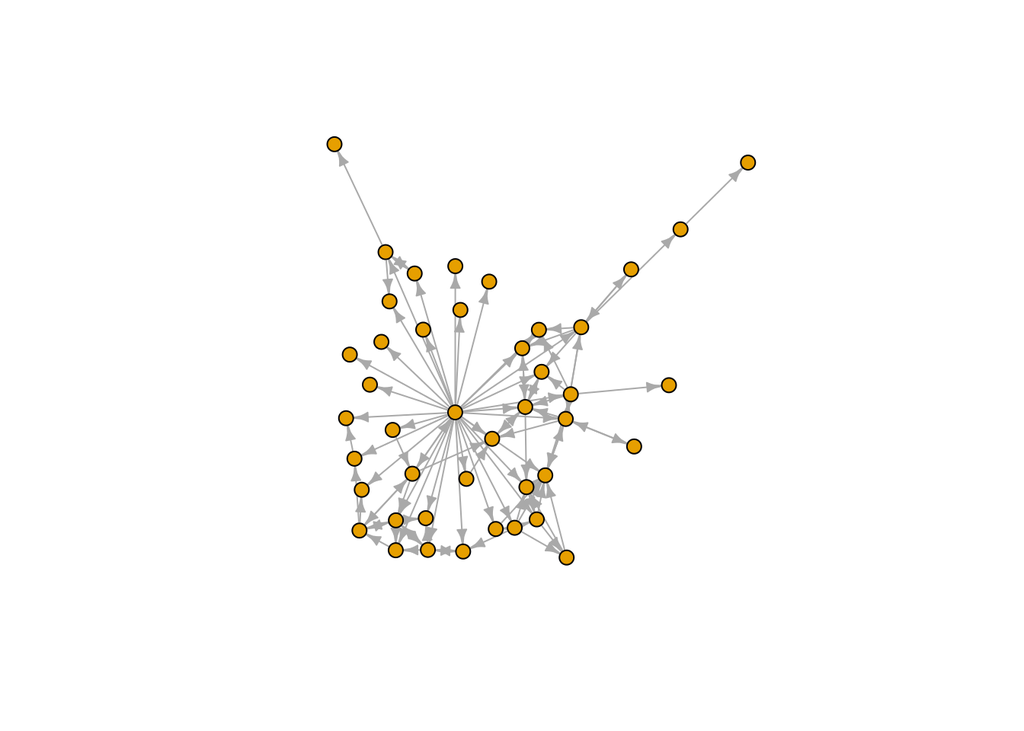

```r
enr.com1<-induced.subgraph(enr.crisis, V(enr.crisis)$membership==1)
plot(simplify(enr.com1), edge.arrow.size=0.5, vertex.label=NA, vertex.size=7)
```

```r
deg.com1<-degree(enr.com1)
deg.com1
```

```
##  [1]  42  11  16  29  28  18  12  80  27  41  46   2  27  38  18  16  16
## [18]  28  55  24  24  44  18  23  54  15   2  32  20  72  48  16  58  33
## [35]  16  22 563   7  33  55  16   8  61
```

### Ego Networks

We can extract the networks of an individual within the network, making them an ego and everyone else an alter. This can be handy when analyzing ego-network data where all of the nodes may be in the same file even though they represent specific cases.

```r
enr.egos<-make_ego_graph(enr.com1, 1)
```

This makes a list with ego networks for all of the members of a network. We can extract a specific element using the numerical index – [[1]] for the first ego network and [[2]] for the second – or we can name each network and use $ to pull them out.

```r
names(enr.egos)<-V(enr.com1)$Name
head(enr.egos)
```

```
## $`Thomas Martin`
## IGRAPH D--- 7 139 -- Enron email network
## + attr: LDC_names (g/c), LDC_desc (g/c), name (g/c), Citation
## | (g/c), Email (v/c), Name (v/c), Note (v/c), id (v/c), in.degree
## | (v/n), out.degree (v/n), eigen.cent (v/n), total.degree (v/n),
## | membership (v/n), Time (e/c), Reciptype (e/c), Topic (e/n),
## | LDC_topic (e/n), month (e/n), year (e/n), day (e/n)
## + edges:
##  [1] 1->3 1->3 1->3 1->4 2->1 2->1 2->1 2->1 2->3 4->2 4->3 5->1 5->1 5->1
## [15] 5->1 5->1 5->1 5->1 5->1 5->1 5->1 5->1 5->1 5->2 5->2 5->2 5->2 5->2
## [29] 5->2 5->3 5->3 5->3 5->3 5->3 5->3 5->4 5->4 5->4 5->4 5->4 5->4 6->1
## [43] 6->1 6->1 6->1 6->1 6->1 6->1 6->1 6->1 6->1 6->1 6->1 6->1 6->1 6->1
## + ... omitted several edges
##
## $`Andrea Ring`
## IGRAPH D--- 3 14 -- Enron email network
## + attr: LDC_names (g/c), LDC_desc (g/c), name (g/c), Citation
## | (g/c), Email (v/c), Name (v/c), Note (v/c), id (v/c), in.degree
## | (v/n), out.degree (v/n), eigen.cent (v/n), total.degree (v/n),
## | membership (v/n), Time (e/c), Reciptype (e/c), Topic (e/n),
## | LDC_topic (e/n), month (e/n), year (e/n), day (e/n)
## + edges:
##  [1] 1->3 1->3 1->3 1->3 1->3 1->3 1->3 2->1 2->1 2->1 2->1 2->2 2->2 2->2
##
## $`Andy Zipper`
## IGRAPH D--- 2 18 -- Enron email network
## + attr: LDC_names (g/c), LDC_desc (g/c), name (g/c), Citation
## | (g/c), Email (v/c), Name (v/c), Note (v/c), id (v/c), in.degree
## | (v/n), out.degree (v/n), eigen.cent (v/n), total.degree (v/n),
## | membership (v/n), Time (e/c), Reciptype (e/c), Topic (e/n),
## | LDC_topic (e/n), month (e/n), year (e/n), day (e/n)
## + edges:
##  [1] 2->1 2->1 2->1 2->1 2->1 2->1 2->1 2->1 2->1 2->1 2->1 2->1 2->1 2->1
## [15] 2->1 2->1 2->2 2->2
##
## $`Benjamin Rogers`
## IGRAPH D--- 6 113 -- Enron email network
## + attr: LDC_names (g/c), LDC_desc (g/c), name (g/c), Citation
## | (g/c), Email (v/c), Name (v/c), Note (v/c), id (v/c), in.degree
## | (v/n), out.degree (v/n), eigen.cent (v/n), total.degree (v/n),
```

[output cut: 18 more lines]

```
## [15] 4->1 4->1 4->1 4->1 4->4 4->4 4->4 4->4 4->4 4->4 4->4 4->4 4->4 4->4
## [29] 4->4 4->4 4->4 4->4 4->4 4->4 5->1 5->1 5->1 5->1 5->1 5->1 5->1 5->1
## [43] 5->1 5->1 5->1 5->1 5->1 5->1 5->1 5->1 5->2 5->2 5->2 5->2 5->2 5->2
## + ... omitted several edges
##
## $`Daron Giron`
## IGRAPH D--- 2 16 -- Enron email network
## + attr: LDC_names (g/c), LDC_desc (g/c), name (g/c), Citation
## | (g/c), Email (v/c), Name (v/c), Note (v/c), id (v/c), in.degree
## | (v/n), out.degree (v/n), eigen.cent (v/n), total.degree (v/n),
## | membership (v/n), Time (e/c), Reciptype (e/c), Topic (e/n),
## | LDC_topic (e/n), month (e/n), year (e/n), day (e/n)
## + edges:
##  [1] 1->1 1->1 1->2 1->2 1->2 2->1 2->1 2->1 2->1 2->1 2->1 2->1 2->1 2->1
## [15] 2->1 2->1
```

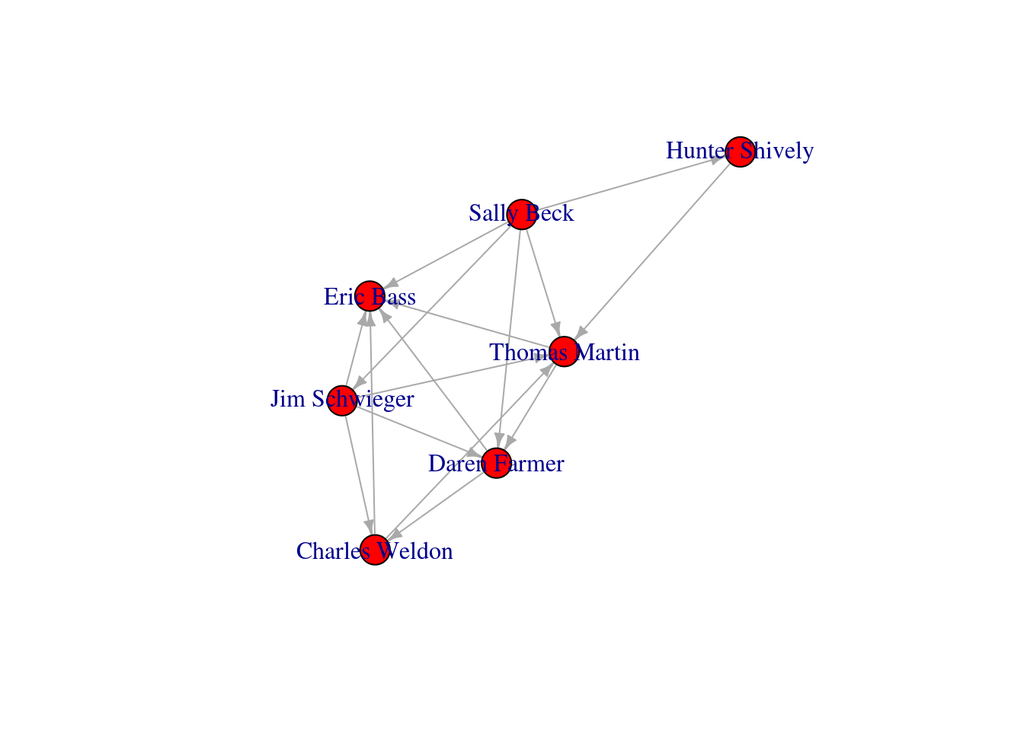

```r
enr.ego.one<-enr.egos[[1]]
plot(simplify(enr.ego.one), vertex.color='red', edge.arrow.size=0.5, vertex.label=V(enr.ego.one)$Name)
```

```r
enr.egos$'Eric Bass'
```

```
## IGRAPH D--- 9 199 -- Enron email network
## + attr: LDC_names (g/c), LDC_desc (g/c), name (g/c), Citation
## | (g/c), Email (v/c), Name (v/c), Note (v/c), id (v/c), in.degree
## | (v/n), out.degree (v/n), eigen.cent (v/n), total.degree (v/n),
## | membership (v/n), Time (e/c), Reciptype (e/c), Topic (e/n),
## | LDC_topic (e/n), month (e/n), year (e/n), day (e/n)
## + edges:
##  [1] 1->3 1->3 1->3 1->4 2->1 2->1 2->1 2->1 2->3 3->8 3->8 3->8 3->8 4->2
## [15] 4->3 5->1 5->1 5->1 5->1 5->1 5->1 5->1 5->1 5->1 5->1 5->1 5->1 5->2
## [29] 5->2 5->2 5->2 5->2 5->2 5->3 5->3 5->3 5->3 5->3 5->3 5->4 5->4 5->4
## [43] 5->4 5->4 5->4 5->6 5->6 5->6 5->6 5->6 5->6 6->3 6->3 7->3 7->3 7->3
## + ... omitted several edges
```

```r
enr.egos['Eric Bass']
```

```
## $`Eric Bass`
## IGRAPH D--- 9 199 -- Enron email network
## + attr: LDC_names (g/c), LDC_desc (g/c), name (g/c), Citation
## | (g/c), Email (v/c), Name (v/c), Note (v/c), id (v/c), in.degree
## | (v/n), out.degree (v/n), eigen.cent (v/n), total.degree (v/n),
## | membership (v/n), Time (e/c), Reciptype (e/c), Topic (e/n),
## | LDC_topic (e/n), month (e/n), year (e/n), day (e/n)
## + edges:
##  [1] 1->3 1->3 1->3 1->4 2->1 2->1 2->1 2->1 2->3 3->8 3->8 3->8 3->8 4->2
## [15] 4->3 5->1 5->1 5->1 5->1 5->1 5->1 5->1 5->1 5->1 5->1 5->1 5->1 5->2
## [29] 5->2 5->2 5->2 5->2 5->2 5->3 5->3 5->3 5->3 5->3 5->3 5->4 5->4 5->4
## [43] 5->4 5->4 5->4 5->6 5->6 5->6 5->6 5->6 5->6 6->3 6->3 7->3 7->3 7->3
## + ... omitted several edges
```

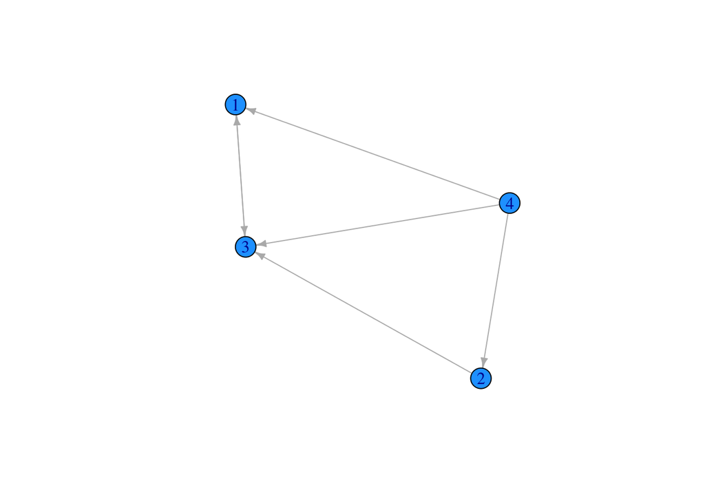

```r
plot(simplify(enr.egos$'Kenneth Lay'), vertex.color='dodger blue', edge.arrow.size=0.5)
```

When running stats on a list we can use the lapply function to use a single bit of code on the entire list. Basically lapply has three parts. First a list that will be processed, then an argument called the function that assigns a temporary name to each item on the list as we iterate through it, finally the actual code with the temporary name subbed in. In this case lapply is working through the list of networks, any one of which is represented by *x*, for each item in the list we plot it or get the degree count, returning a list of results.

```r
enr.deg.ego<-lapply(enr.egos, function(x) degree(x))
head(enr.deg.ego)
```

```
## $`Thomas Martin`
## [1] 42 12 27 28 46 89 34
##
## $`Andrea Ring`
## [1] 11 10  7
##
## $`Andy Zipper`
## [1] 16 20
##
## $`Benjamin Rogers`
## [1] 29 65 22 12 22 76
##
## $`Bradley Mckay`
## [1] 28 24 30 52 70
##
## $`Daron Giron`
## [1] 18 14
```

```r
enr.deg.ego.df<-data.frame(degree=enr.deg.ego$"Kenneth Lay")
enr.deg.ego.df
```

```
##   degree
## 1     20
## 2     19
## 3     15
## 4     44
```

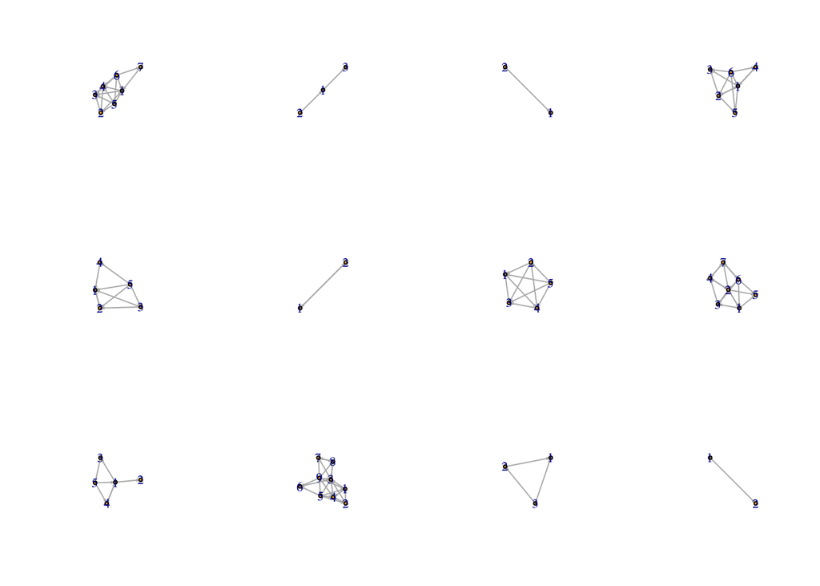

```
## $`Thomas Martin`
## NULL
##
## $`Andrea Ring`
## NULL
##
## $`Andy Zipper`
## NULL
##
## $`Benjamin Rogers`
## NULL
##
## $`Bradley Mckay`
## NULL
##
## $`Daron Giron`
## NULL
##
## $`Charles Weldon`
## NULL
##
## $`Dana Davis`
## NULL
##
## $`Don Baughman`
## NULL
##
## $`Eric Bass`
## NULL
##
## $`Eric Saibi`
## NULL
##
## $`Larry Campbell`
## NULL
```

```r
par(mfrow=c(3,4))
lapply(enr.egos[1:12], function(x) plot(simplify(x), edge.arrow.size=0.1))
```

### Putting it all together.

Let’s combine everything we learned and look at how the Enron network evolved over the course of October 16th, the day things started to get REALLY bad for the company. First let’s create a new edge attribute, the hour of day an email was sent. Then let’s grab all of the emails from 2001-10-16 in one big subgraph. Finally we’ll create a vector of hours and iterate through it, generating a new subgraph and running community detection at each phase.

```r
E(enr)$hour<-hour(E(enr)$Time)
enr.day<-subgraph.edges(enr, which(E(enr)$year==2001 & E(enr)$month==10 & E(enr)$day==16))
l=layout.fruchterman.reingold(enr.day)
hours<-c(9,11,13,15,18,20)
```

```r
email.evolve<-lapply(hours, function(q)
  subgraph.edges(enr.day, which(E(enr.day)$hour<=q)))
head(email.evolve)
```

```
## [[1]]
## IGRAPH D--- 7 5 -- Enron email network
## + attr: LDC_names (g/c), LDC_desc (g/c), name (g/c), Citation
## | (g/c), Email (v/c), Name (v/c), Note (v/c), id (v/c), in.degree
## | (v/n), out.degree (v/n), eigen.cent (v/n), total.degree (v/n),
## | Time (e/c), Reciptype (e/c), Topic (e/n), LDC_topic (e/n), month
## | (e/n), year (e/n), day (e/n), hour (e/n)
## + edges:
## [1] 7->3 7->3 1->5 2->4 2->6
##
## [[2]]
## IGRAPH D--- 27 42 -- Enron email network
## + attr: LDC_names (g/c), LDC_desc (g/c), name (g/c), Citation
## | (g/c), Email (v/c), Name (v/c), Note (v/c), id (v/c), in.degree
## | (v/n), out.degree (v/n), eigen.cent (v/n), total.degree (v/n),
## | Time (e/c), Reciptype (e/c), Topic (e/n), LDC_topic (e/n), month
## | (e/n), year (e/n), day (e/n), hour (e/n)
## + edges:
##  [1] 21-> 9 21-> 9  2->19  6->16  6->20  7-> 3  7-> 3  7-> 3  7-> 3  7->11
## [11]  7->11  7->11  7->11  4-> 4  5->22 24->23 23->24 23->24  4->26 25->26
## [21] 12->14 12->18 13-> 1 15-> 8 15-> 8 15-> 8 15->27 15->27 15->27 15->27
## [31] 15->27 15->27 15->27 15->27  8->15  8->15  1->13 15->27 15->27 13->10
## + ... omitted several edges
##
## [[3]]
## IGRAPH D--- 41 93 -- Enron email network
## + attr: LDC_names (g/c), LDC_desc (g/c), name (g/c), Citation
## | (g/c), Email (v/c), Name (v/c), Note (v/c), id (v/c), in.degree
## | (v/n), out.degree (v/n), eigen.cent (v/n), total.degree (v/n),
## | Time (e/c), Reciptype (e/c), Topic (e/n), LDC_topic (e/n), month
## | (e/n), year (e/n), day (e/n), hour (e/n)
## + edges:
##  [1] 32->15 32->15  2->30 10->27 10->31 11-> 4 11-> 4 11-> 4 11-> 4 11->18
## [11] 11->18 11->18 11->18  5-> 5  6->33 36->34 34->36 34->36  5->38 37->38
## [21] 21->25 21->29 22-> 1 26->12 26->12 26->12 26->39 26->39 26->39 26->39
## [31] 26->39 26->39 26->39 26->39 12->26 12->26  1->22 26->39 26->39 22->17
## + ... omitted several edges
##
## [[4]]
## IGRAPH D--- 51 124 -- Enron email network
```

[output cut: 24 more lines]

```
## + ... omitted several edges
##
## [[6]]
## IGRAPH D--- 76 391 -- Enron email network
## + attr: LDC_names (g/c), LDC_desc (g/c), name (g/c), Citation
## | (g/c), Email (v/c), Name (v/c), Note (v/c), id (v/c), in.degree
## | (v/n), out.degree (v/n), eigen.cent (v/n), total.degree (v/n),
## | Time (e/c), Reciptype (e/c), Topic (e/n), LDC_topic (e/n), month
## | (e/n), year (e/n), day (e/n), hour (e/n)
## + edges:
##  [1] 62->29 62->29  2->57 18->50 18->58 21-> 6 21-> 6 21-> 6 21-> 6 21->35
## [11] 21->35 21->35 21->35  7-> 7 11->64 69->66 66->69 66->69  7->72 70->72
## [21] 42->48 42->54 45-> 1 49->24 49->24 49->24 49->73 49->73 49->73 49->73
## [31] 49->73 49->73 49->73 49->73 24->49 24->49  1->45 49->73 49->73 45->34
## + ... omitted several edges
```

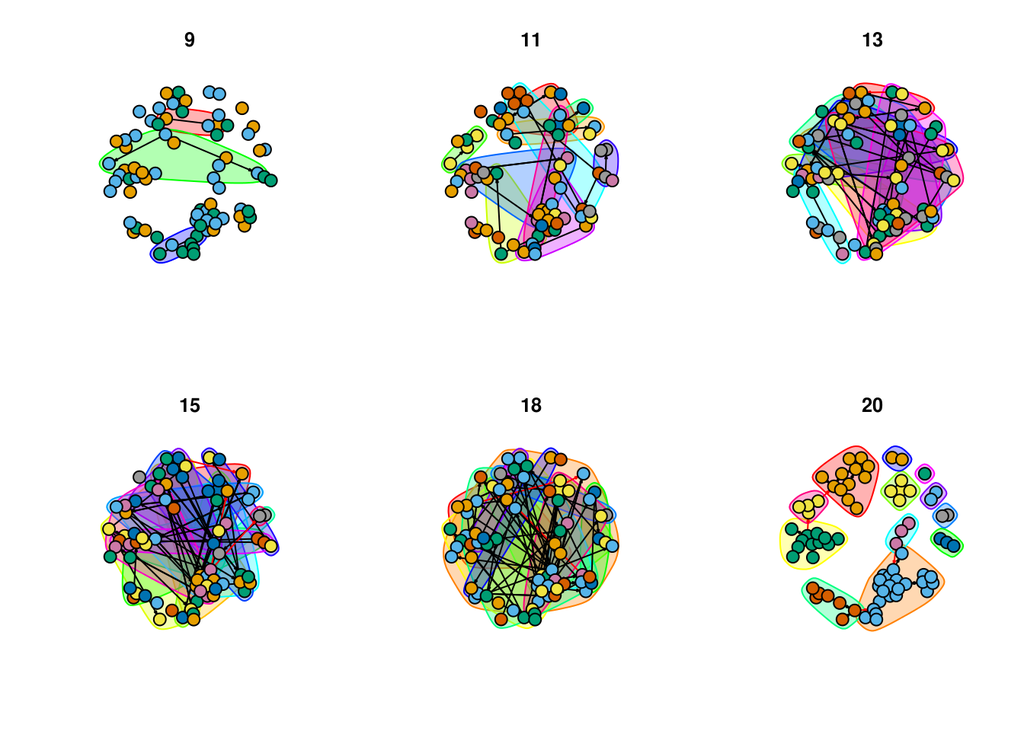

```r
par(mfrow=c(2,3))
lapply(email.evolve, function(x)
  plot(edge.betweenness.community(x), simplify(x), edge.arrow.size=0.1, vertex.label=NA, layout=l, main=max(E(x)$hour)))
```

All of these techniques are exceptionally helpful for studying networks from an evolutionary perspective. In the next few weeks you’ll use these tools